# ACME camera script for SRFN project

Marissa A. Dyck

2024-12-11

# Before you begin

## Contact Info

If you have question please email the most recent author, currently

Marissa A. Dyck  
Postdoctoral research fellow  
University of Victoria  
School of Environmental Studies  
Email: marissadyck17@gmail.com

## R markdown

This script is written in R markdown and thus uses a mix of coding markup languages and R. If you are planning to run this script with new data or make any modifications you will want to be familiar with some basics of R markdown.

Below is an R markdown cheatsheet to help you get started,  
[R markdown cheatsheet](https://www.rstudio.com/wp-content/uploads/2015/02/rmarkdown-cheatsheet.pdf)

## Install packages

If you don’t already have the following packages installed, use the code below to install them.

```r
install.packages('tidyverse')
```

## Load libraries

Then load the packages to your library.

```r
library('tidyverse') # data tidying, visualization, and much more; this will load all tidyverse packages, can see complete list using tidyverse_packages()
```

# Deployment data

Let’s start by importing the deployment data so we know how many cameras there are, info on the site names and locations for the study

## Import deployment data

Let’s import the deployment data file and check the data for any issues

```r
# read in deployment data file
deploy <- read_csv('data/raw/deployment_srfn.csv',

                   # specify how we want the columns read in
                   col_types = cols(Project.ID = col_factor(),
                                    Deployment.Location.ID = col_factor(),

                                     # the format for dates must match the format that the dates are entered in the csv file (run ?col_date in the console to get mmore info)
                                    Camera.Deployment.Begin.Date. = col_date(
                                      format = "%m/%d/%Y"),
                                    Camera.Deployment.End.Date = col_date(
                                      format = "%m/%d/%Y"),

                                    .default = col_character())) %>%

   # change the column names to lowercase to reduce keystrokes and errors when typing
set_names(
    names(.) %>%
      tolower() %>%

      # get rid of periods in the data and replace with underscores to match other data files and maintain best coding practices
      str_replace_all(pattern = '\\.',
                      replacement = '_'))
```

> Open the data file from the environment by clicking on it to check that it looks good

## Data checks

### Structure

Make sure columns imported correctly

```r
# make sure the columns read in properly

str(deploy)
```

```
## spc_tbl_ [64 × 4] (S3: spec_tbl_df/tbl_df/tbl/data.frame)
##  $ project_id                   : Factor w/ 1 level "SRFN": 1 1 1 1 1 1 1 1 1 1 ...
##  $ deployment_location_id       : Factor w/ 64 levels "1","2","4","6",..: 1 2 3 4 5 6 7 8 9 10 ...
##  $ camera_deployment_begin_date_: Date[1:64], format: "2022-04-06" "2022-04-07" ...
##  $ camera_deployment_end_date   : Date[1:64], format: "2023-10-03" "2023-10-04" ...
##  - attr(*, "spec")=
##   .. cols(
##   ..   .default = col_character(),
##   ..   Project.ID = col_factor(levels = NULL, ordered = FALSE, include_na = FALSE),
##   ..   Deployment.Location.ID = col_factor(levels = NULL, ordered = FALSE, include_na = FALSE),
##   ..   Camera.Deployment.Begin.Date. = col_date(format = "%m/%d/%Y"),
##   ..   Camera.Deployment.End.Date = col_date(format = "%m/%d/%Y")
##   .. )
##  - attr(*, "problems")=<externalptr>
```

```r
# everything looks good
```

### Sites

Let’s check the levels for the landscape units (project_id) and the sites (deployment_location_id) to make sure they look correct, this is the file we will base the rest of the data checks on for the timelapse and covariate data so we want to make sure it is correct

```r
# let's check the levels for the landscape units (project_id) and the sites (deployment_location_id) to make sure they match the other data

levels(deploy$project_id)
```

```
## [1] "SRFN"
```

```r
levels(deploy$deployment_location_id)
```

```
##  [1] "1"   "2"   "4"   "6"   "10"  "12"  "13"  "17"  "18"  "21"  "23"  "24"
## [13] "26"  "30"  "31"  "35"  "37"  "38"  "39"  "42"  "44"  "45"  "46"  "51"
## [25] "55"  "56"  "58"  "60"  "62"  "63"  "67"  "70"  "74"  "75"  "77"  "81"
## [37] "83"  "88"  "94"  "95"  "99"  "100" "104" "105" "107" "110" "117" "118"
## [49] "119" "120" "121" "124" "125" "126" "130" "131" "132" "136" "137" "140"
## [61] "141" "163" "165" "166"
```

> I don’t know all the details of project based on looking at other data files this deployment file is missing some information we will want later
1. The sites are just numbers but in other files the site names are accompanied by an identified for the landscape unit category before the number so we will need to fix this
2. Also there should be a separate column for the landscape unit category (array)

### NAs

Let’s check that there aren’t any NAs, if everything worked w/ no issues and was entered correctly there shouldn’t be any NAs in this file

```r
# check that there aren't any NAs
summary(deploy)
```

```
##  project_id deployment_location_id camera_deployment_begin_date_
##  SRFN:64    1      : 1             Min.   :2022-03-30
##             2      : 1             1st Qu.:2022-04-07
##             4      : 1             Median :2022-04-17
##             6      : 1             Mean   :2022-05-09
##             10     : 1             3rd Qu.:2022-05-11
##             12     : 1             Max.   :2023-01-14
##             (Other):58
##  camera_deployment_end_date
##  Min.   :2022-09-27
##  1st Qu.:2023-07-06
##  Median :2023-09-19
##  Mean   :2023-08-03
##  3rd Qu.:2023-10-03
##  Max.   :2024-01-09
##
```

No NAs so we are good

## Data formatting

We need to fix a couple things to make this data file work for our purposes later, in order to get the landscape unit info we will need to join this data with another file in the raw data called reference.csv

> In the future I would recommend having one data file with all the necessary information and simplifying the column names so they match what we need to use later (e.g. array, site, start_date, end_date, etc.)

First lets format the deploy data

```r
deploy_fixed <- deploy %>%

  # change column names
  rename(site_number = deployment_location_id,
         start_date = camera_deployment_begin_date_,
         end_date = camera_deployment_end_date)
```

Now let’s remove the messy data so we don’t accidentally use it later

```r
rm(deploy)
```

### Import reference data

Now lets import the reference.csv we need

```r
sites <- read_csv('data/raw/reference.csv',

                  # specify column types
                  col_types = cols(.default = col_factor())) %>%

# I don't like the original column names I think they are confusing so I'm quick going to change them here
rename(site_number = site,
       site = real_site)
```

### Join data and reformat

Now we need to join the deploy_fixed with the sites data file so we have all the info we need in one spot

```r
deploy_fixed <- deploy_fixed %>%

  full_join(sites,
            by = 'site_number')
```

Okay now that this has the info we need we just want to generate one more column and reorganize the data. We need a column for landscape unit (array) which we can extract from the site column

```r
deploy_fixed <- deploy_fixed %>%

  # extract the data from the site column before the underscore
  mutate(array = str_extract(site, "^[^_]+"),

         #convert site_number to factor
         site_number = as.factor(site_number)) %>%

  #rearrange the columns
  relocate(site, array, .after = site_number)
```

> Now we have everything we need let’s double check the data looks good

Let’s check that the sites all matched up okay from the reference files (sites) to the deployment data

```r
summary(deploy_fixed$site)
```

```
##    LUD_1    LUC_2    LUC_4    LUS_6   LUS_10  LUBF_12   LUC_13   LUC_17
##        1        1        1        1        1        1        1        1
##   LUC_18   LUC_21   LUC_23   LUC_24   LUC_26  LUBF_30   LUC_31  LUBF_35
##        1        1        1        1        1        1        1        1
##   LUC_37   LUC_38   LUS_39   LUC_42  LUBF_44   LUC_45  LUBF_46   LUC_51
##        1        1        1        1        1        1        1        1
##  LUBF_55   LUS_56  LUBF_58   LUC_60  LUBF_62  LUBF_63  LUBF_67   LUS_70
##        1        1        1        1        1        1        1        1
##   LUG_74  LUBF_75   LUC_77  LUBF_81  LUBF_83  LUBF_88   LUS_94   LUS_95
##        1        1        1        1        1        1        1        1
##  LUBF_99 LUUK_100 LUBF_104 LUBF_105  LUS_107  LUC_110  LUC_117  LUS_118
##        1        1        1        1        1        1        1        1
## LUAG_119  LUS_120 LUBF_121 LUAG_124  LUW_125 LUBF_126 LUBF_130  LUS_131
##        1        1        1        1        1        1        1        1
## LUBF_132  LUS_136 LUAG_137 LUBF_140  LUC_141 LUUK_163 LUUK_165 LUUK_166
##        1        1        1        1        1        1        1        1
```

```r
summary(deploy_fixed$site_number)
```

```
##   1   2   4   6  10  12  13  17  18  21  23  24  26  30  31  35  37  38  39  42
##   1   1   1   1   1   1   1   1   1   1   1   1   1   1   1   1   1   1   1   1
##  44  45  46  51  55  56  58  60  62  63  67  70  74  75  77  81  83  88  94  95
##   1   1   1   1   1   1   1   1   1   1   1   1   1   1   1   1   1   1   1   1
##  99 100 104 105 107 110 117 118 119 120 121 124 125 126 130 131 132 136 137 140
##   1   1   1   1   1   1   1   1   1   1   1   1   1   1   1   1   1   1   1   1
## 141 163 165 166
##   1   1   1   1
```

Okay that looks good there is one entry per site and no NAs in either column

Let’s check that they match the reference data using a handy function `setdiff()`

```r
# check which sites are in deploy fixed data that are not in sites
setdiff(levels(deploy_fixed$site),
        levels(sites$site))
```

```
## character(0)
```

```r
# and switch the order to check if there are extras in sitest data that are not in deploy fixed
setdiff(levels(sites$site),
        levels(deploy_fixed$site))
```

```
## character(0)
```

No mismatches that’s great!

## Finish with deployment data

### Save deploy data

```r
# save to processed data folder

write_csv(deploy_fixed,
          'data/processed/srfn_deploy_fixed.csv')
```

## Camera operability

We can check the length each camera was operating using the cleaned deployment data, this is important for calculating the proportional presence/absences for analysis later on so we need to make sure nothing looks inaccurate here.

Let’s plot the camera operability with `ggplot()` to look at this

```r
# if starting from this point read in data
deploy_fixed <- read_csv('data/processed/srfn_deploy_fixed.csv') %>%

  # make sure site re-reads in as a factor to compare with other data sets
  mutate(site = as.factor(site))
```

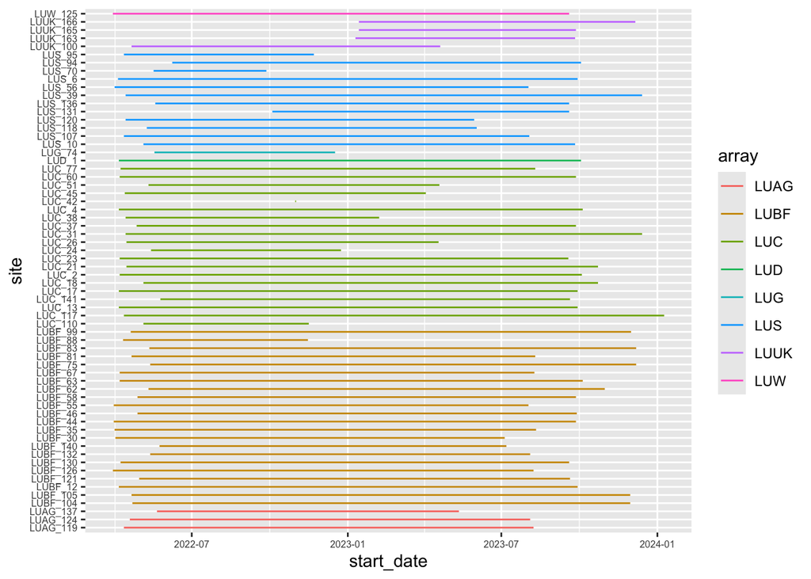

```r
# create graph of camera operability ##KATE edit: in first line it referenced project_id, I changed to "array"

cam_op <- ggplot(deploy_fixed, aes(color = array))+

  geom_segment(aes(x = start_date,
                   xend = end_date,
                   y = site,
                   yend = site)) +

  theme(axis.text = element_text(size = 6))

# view plot
cam_op
```

### Save camera operability

```r
# Save the plot as a jpg
ggsave( "figures/camera_operability.jpg",
        cam_op,
        width = 8,
        height = 6,
        units = 'in',
        dpi = 500)
```

# Timelapse data

This code will import all of the timelapse data files and merge them into one data frame.

Make a list of all the data files and use `map_drf()` to read them in and join them to one data frame (map is a function in the *purrr* package that performs iterations and map_dfr returns data frames by row-binding objects together).

```r
# make a list of all .csv files in the 2. Timelapse Files folder
srfn_data <- list.files(
  path = 'data/raw/timelapse_csvs', # provide the folder/s within the working drive where the files are stored
  pattern = '*.csv*', # provide the extension in case there are other files saved in that folder you don't want to load
  full.names = TRUE) %>%

  map_dfr(~.x %>%
            read_csv(.,

                              # specify how to read in the various columns, if you don't specify this R reads some of the columns in differently for different files and the code won't work to join them. (Still looking for a more efficient way to do this rather than one-by-one but for now this works)
                              col_types = cols(RootFolder = col_character(),
                                               File = col_character(),
                                               RelativePath = col_character(),
                                               Dark = col_logical(),
                                               DeleteFlag = col_logical(),
                                               Site = col_factor(),
                                               Classifier = col_factor(),
                                               Snow = col_factor(),
                                               Species = col_factor(),
                                               Event = col_character(),
                                               Empty = col_logical(),
                                               CoatColour = col_character(),
                                               CameraMalfunction = col_factor(),
                                               OtherSpecify = col_character(),
                                               Comments = col_character(),
                                               Noteworthy = col_logical(),
                                               DateTime = col_datetime(format = "%Y-%m-%d %H:%M:%S"),
                                               .default = col_integer())) %>%  #.default sets any unspecified columns to this type

           # set the column names to lowercase, this makes it easier to avoid case-sensitive mistakes when coding
           set_names(
             names(.) %>%
               tolower()))
```

## Data checks

### Data structure

Check the internal structure of the data using the `str()` function.

This should all be good since we specified how to read in each variable above, but if new columns are added from the Timelapse program/process, that could change things each year so we should double check anyways.

```r
# check the internal structure
str(srfn_data)
```

```
## spc_tbl_ [910,413 × 38] (S3: spec_tbl_df/tbl_df/tbl/data.frame)
##  $ rootfolder       : chr [1:910413] "100RECNX" "100RECNX" "100RECNX" "100RECNX" ...
##  $ file             : chr [1:910413] "RCNX0001.JPG" "RCNX0002.JPG" "RCNX0003.JPG" "RCNX0004.JPG" ...
##  $ relativepath     : chr [1:910413] NA NA NA NA ...
##  $ deleteflag       : logi [1:910413] FALSE FALSE FALSE FALSE FALSE FALSE ...
##  $ site             : Factor w/ 65 levels "100","104","105",..: 1 1 1 1 1 1 1 1 1 1 ...
##  $ classifier       : Factor w/ 11 levels "styles","kris",..: 1 1 1 1 1 1 1 1 1 1 ...
##  $ snow             : Factor w/ 5 levels "<50","0",">50",..: 1 1 1 1 1 1 1 1 1 2 ...
##  $ species          : Factor w/ 30 levels "White-tailed deer",..: NA NA NA NA NA NA NA NA NA NA ...
##  $ total            : int [1:910413] 0 0 0 0 0 0 0 0 0 0 ...
##  $ male             : int [1:910413] 0 0 0 0 0 0 0 0 0 0 ...
##  $ female           : int [1:910413] 0 0 0 0 0 0 0 0 0 0 ...
##  $ unknownsex       : int [1:910413] 0 0 0 0 0 0 0 0 0 0 ...
##  $ adult            : int [1:910413] 0 0 0 0 0 0 0 0 0 0 ...
##  $ yly              : int [1:910413] 0 0 0 0 0 0 0 0 0 0 ...
##  $ yoy              : int [1:910413] 0 0 0 0 0 0 0 0 0 0 ...
##  $ unknownage       : int [1:910413] NA NA NA NA NA NA NA NA NA NA ...
##  $ group_count      : int [1:910413] NA NA NA NA NA NA NA NA NA NA ...
##  $ g_male           : int [1:910413] NA NA NA NA NA NA NA NA NA NA ...
##  $ g_female         : int [1:910413] NA NA NA NA NA NA NA NA NA NA ...
##  $ g_unknownsex     : int [1:910413] NA NA NA NA NA NA NA NA NA NA ...
##  $ g_adult          : int [1:910413] NA NA NA NA NA NA NA NA NA NA ...
##  $ g_yly            : int [1:910413] NA NA NA NA NA NA NA NA NA NA ...
##  $ g_yoy            : int [1:910413] NA NA NA NA NA NA NA NA NA NA ...
##  $ gunknownage      : int [1:910413] NA NA NA NA NA NA NA NA NA NA ...
##  $ event            : chr [1:910413] NA NA NA NA ...
##  $ empty            : logi [1:910413] FALSE FALSE FALSE FALSE FALSE FALSE ...
##  $ coatcolour       : chr [1:910413] NA NA NA NA ...
##  $ leftantler       : int [1:910413] NA NA NA NA NA NA NA NA NA NA ...
##  $ rightantler      : int [1:910413] NA NA NA NA NA NA NA NA NA NA ...
##  $ lcount           : int [1:910413] NA NA NA NA NA NA NA NA NA NA ...
##  $ rcount           : int [1:910413] NA NA NA NA NA NA NA NA NA NA ...
##  $ cameramalfunction: Factor w/ 6 levels "Trigger malfunction",..: NA NA NA NA NA NA NA NA NA NA ...
##  $ otherspecify     : chr [1:910413] NA NA NA NA ...
##  $ comments         : chr [1:910413] "noon" "noon" "noon" "noon" ...
##  $ noteworthy       : logi [1:910413] FALSE FALSE FALSE FALSE FALSE FALSE ...
##  $ datetime         : POSIXct[1:910413], format: "2022-04-21 12:00:00" "2022-04-21 12:05:00" ...
##  $ choice0          : int [1:910413] NA NA NA NA NA NA NA NA NA NA ...
##  $ ...38            : int [1:910413] NA NA NA NA NA NA NA NA NA NA ...
##  - attr(*, "spec")=
```

[output cut: 27 more lines]

```
##   ..   Empty = col_logical(),
##   ..   CoatColour = col_character(),
##   ..   LeftAntler = col_integer(),
##   ..   RightAntler = col_integer(),
##   ..   LCount = col_integer(),
##   ..   RCount = col_integer(),
##   ..   CameraMalfunction = col_factor(levels = NULL, ordered = FALSE, include_na = FALSE),
##   ..   OtherSpecify = col_character(),
##   ..   Comments = col_character(),
##   ..   Noteworthy = col_logical(),
##   ..   DateTime = col_datetime(format = "%Y-%m-%d %H:%M:%S"),
##   ..   Choice0 = col_integer(),
##   ..   ...38 = col_integer()
##   .. )
##  - attr(*, "problems")=<externalptr>
```

The variables all look like they uploaded with the correct format

### Column names

We can use the `names()` function to check that all the column names are correct and match with other year’s of OSM data

```r
names(srfn_data)
```

```
##  [1] "rootfolder"        "file"              "relativepath"
##  [4] "deleteflag"        "site"              "classifier"
##  [7] "snow"              "species"           "total"
## [10] "male"              "female"            "unknownsex"
## [13] "adult"             "yly"               "yoy"
## [16] "unknownage"        "group_count"       "g_male"
## [19] "g_female"          "g_unknownsex"      "g_adult"
## [22] "g_yly"             "g_yoy"             "gunknownage"
## [25] "event"             "empty"             "coatcolour"
## [28] "leftantler"        "rightantler"       "lcount"
## [31] "rcount"            "cameramalfunction" "otherspecify"
## [34] "comments"          "noteworthy"        "datetime"
## [37] "choice0"           "...38"
```

Because there are slight differences in the number/order of columns between files, R creates an extra columns ( …38) which we will delete later.

We also need to add a month and year column for future data processing steps, we can extract these columns from the datetime column in the data formatting below

Lastly we need the site column to match the sites from the deployment data and add an array column.

> Before we proceed with additional data checks let’s get these things fixed now and see what remains issues for later

## Data manipulation part 1

```r
srfn_data_fixed <- srfn_data %>%

  # first rename site to site_number so we can join with the 'sites' data file
  rename(site_number = site) %>%

  # now join with the sites data so we have the right site and array info
  left_join(sites,
            by = 'site_number') %>%

  # add month and year columns from the datetime data for merging with other files later
  mutate(month = month(datetime),
         year = year(datetime),

         # add array column from the site column
         array = str_extract(site, "^[^_]+")) %>%

  # remove columns we won't be using to simplify the data file
  select(!c(rootfolder:deleteflag,
            classifier,
            otherspecify:noteworthy,
            choice0,
            ...38
            )) %>%

  # move the site and array column next to site number
  relocate(site, array,
           .after = site_number)
```

Okay now that we have all the columns we need we can do some more data checks

Let’s remove the messy data first

```r
rm(srfn_data)
```

### Sites

Based on the deployment data there are 64 sites, lets see if we have the same number and the site names match (the names should match since we joined them from the reference (sites) file)

```r
# check that all the sites are accounted for
levels(srfn_data_fixed$site)
```

```
##  [1] "LUD_1"    "LUC_2"    "LUC_4"    "LUS_6"    "LUS_10"   "LUBF_12"
##  [7] "LUC_13"   "LUC_17"   "LUC_18"   "LUC_21"   "LUC_23"   "LUC_24"
## [13] "LUC_26"   "LUBF_30"  "LUC_31"   "LUBF_35"  "LUC_37"   "LUC_38"
## [19] "LUS_39"   "LUC_42"   "LUBF_44"  "LUC_45"   "LUBF_46"  "LUC_51"
## [25] "LUBF_55"  "LUS_56"   "LUBF_58"  "LUC_60"   "LUBF_62"  "LUBF_63"
## [31] "LUBF_67"  "LUS_70"   "LUG_74"   "LUBF_75"  "LUC_77"   "LUBF_81"
## [37] "LUBF_83"  "LUBF_88"  "LUS_94"   "LUS_95"   "LUBF_99"  "LUUK_100"
## [43] "LUBF_104" "LUBF_105" "LUS_107"  "LUC_110"  "LUC_117"  "LUS_118"
## [49] "LUAG_119" "LUS_120"  "LUBF_121" "LUAG_124" "LUW_125"  "LUBF_126"
## [55] "LUBF_130" "LUS_131"  "LUBF_132" "LUS_136"  "LUAG_137" "LUBF_140"
## [61] "LUC_141"  "LUUK_163" "LUUK_165" "LUUK_166"
```

This site column looks good but we wouldn’t sexpect issues since we joined that from the reference (sites) data, lets check the site_number column as well

```r
levels(srfn_data_fixed$site_number)
```

```
##  [1] "100" "104" "105" "107" "118" "119" "12"  "121" "13"  "130" "137" "140"
## [13] "141" "1"   "2"   "23"  "24"  "30"  "37"  "4"   "45"  "46"  "51"  "55"
## [25] "56"  "58"  "6"   "60"  "62"  "9"   "67"  "75"  "77"  "81"  "88"  "94"
## [37] "99"  "35"  "63"  "10"  "110" "117" "120" "124" "125" "126" "131" "132"
## [49] "136" "163" "165" "166" "17"  "18"  "21"  "26"  "31"  "38"  "39"  "42"
## [61] "44"  "70"  "74"  "83"  "95"
```

There appear to be 65 sites in the site_number column instead of 64, so this doesn’t match with the reference file perfectly, let’s explore this more

```r
summary(srfn_data_fixed$site)
```

```
##    LUD_1    LUC_2    LUC_4    LUS_6   LUS_10  LUBF_12   LUC_13   LUC_17
##    83598     1519     2427     6214     1701     2279    47750     2968
##   LUC_18   LUC_21   LUC_23   LUC_24   LUC_26  LUBF_30   LUC_31  LUBF_35
##     2018     2190     5158     4011     2722     2925     3549     4898
##   LUC_37   LUC_38   LUS_39   LUC_42  LUBF_44   LUC_45  LUBF_46   LUC_51
##     2446    57757    12158    51317     5236     1828     2650     1596
##  LUBF_55   LUS_56  LUBF_58   LUC_60  LUBF_62  LUBF_63  LUBF_67   LUS_70
##     6832     8909     1464    25088     3010     4428     1944    43817
##   LUG_74  LUBF_75   LUC_77  LUBF_81  LUBF_83  LUBF_88   LUS_94   LUS_95
##    57774     7743     5248     2849    13949     2055    13559    12839
##  LUBF_99 LUUK_100 LUBF_104 LUBF_105  LUS_107  LUC_110  LUC_117  LUS_118
##     3735     3062     3104     2741     2773     9804    19672     5227
## LUAG_119  LUS_120 LUBF_121 LUAG_124  LUW_125 LUBF_126 LUBF_130  LUS_131
##     2706     4188     4341    11130    46442    49448    14646     6145
## LUBF_132  LUS_136 LUAG_137 LUBF_140  LUC_141 LUUK_163 LUUK_165 LUUK_166
##    89119     8926     8707    64953     9334     1168    13314     1881
##     NA's
##     1424
```

Yup it looks like the reference data file (sites) was maybe missing a site_number that we have in the timelapse data, we can check if there’s a mismatch somewhere using the `setdiff()` argument.

```r
# check which sites are in timelapse data that are not in deployment
setdiff(levels(srfn_data_fixed$site),
        levels(deploy_fixed$site))
```

```
## character(0)
```

```r
# and switch the order to check if there are extras in deployment data compared to timelapse
setdiff(levels(deploy_fixed$site),
        levels(srfn_data_fixed$site))
```

```
## character(0)
```

```r
# check which sites numbers are in timelapse data that are not in deployment
setdiff(levels(srfn_data_fixed$site_number),
        levels(deploy_fixed$site_number))
```

```
##  [1] "100" "104" "105" "107" "118" "119" "12"  "121" "13"  "130" "137" "140"
## [13] "141" "1"   "2"   "23"  "24"  "30"  "37"  "4"   "45"  "46"  "51"  "55"
## [25] "56"  "58"  "6"   "60"  "62"  "9"   "67"  "75"  "77"  "81"  "88"  "94"
## [37] "99"  "35"  "63"  "10"  "110" "117" "120" "124" "125" "126" "131" "132"
## [49] "136" "163" "165" "166" "17"  "18"  "21"  "26"  "31"  "38"  "39"  "42"
## [61] "44"  "70"  "74"  "83"  "95"
```

```r
# and switch the order to check if there are extras in deployment data compared to timelapse
setdiff(levels(deploy_fixed$site_number),
        levels(srfn_data_fixed$site_number))
```

[output not shown]

> Check with Kaitlin and SRFN folks about site 9 which we have timelapse data for but no deployment data and it wasn’t in the reference.csv

### Species names

Let’s check that all the species names were entered correctly and we don’t have any duplicates with different spelling or something, which is common with wildlife data.

Since we set species as a factor when we imported the data we can also use the the `levels()` function to see all the species names.

```r
# check that all the species names were entered correctly
levels(srfn_data_fixed$species)
```

```
##  [1] "White-tailed deer" "Moose"             "Mule deer"
##  [4] "Unknown ungulate"  "Elk"               "Unknown"
##  [7] "Owl"               "Black bear"        "Coyote"
## [10] "Red fox"           "Grey wolf"         "Other"
## [13] "Lynx"              "ATVer"             "Unknown deer"
## [16] "Grizzly bear"      "Snowshoe hare"     "Fisher"
## [19] "Ruffed grouse"     "Red squirrel"      "Raven"
## [22] "Cougar"            "Unknown bear"      "Human"
## [25] "Spruce grouse"     "Marten"            "Domestic dog"
## [28] "Staff"             "Other birds"       "Hunter"
```

```r
# no glaring issues with species entries
```

No glaring issues here.

### Check for NAs

There are a lot of NAs in this data set, and most of them are fine but we should check that there aren’t NAs for some of the more critical information like the site and datetime columns. We can use the `summary()` function to get a printout of all the variables.

This is also a great way to check for any other glaring issues such as miscounted groups (really large or really small max/min numbers) etc.

```r
# check for NAs in columns that shouldn't have NAs, looking at the summary is also a good way to check for other issues with the data
summary(srfn_data_fixed)
```

```
##   site_number           site           array             snow
##  132    : 89119   LUBF_132: 89119   Length:910413      <50 :203279
##  1      : 83598   LUD_1   : 83598   Class :character   0   :376536
##  140    : 64953   LUBF_140: 64953   Mode  :character   >50 : 46126
##  74     : 57774   LUG_74  : 57774                      Deep:    22
##  38     : 57757   LUC_38  : 57757                      100 :   561
##  (Other):555802   (Other) :555788                      NA's:283889
##  NA's   :  1410   NA's    :  1424
##               species           total             male            female
##  White-tailed deer:145180   Min.   :0        Min.   :0.0      Min.   :0.0
##  Moose            : 19787   1st Qu.:1        1st Qu.:0.0      1st Qu.:0.0
##  Elk              : 10270   Median :1        Median :1.0      Median :1.0
##  Black bear       :  2492   Mean   :1        Mean   :0.6      Mean   :0.7
##  Snowshoe hare    :  2208   3rd Qu.:1        3rd Qu.:1.0      3rd Qu.:1.0
##  (Other)          :  9124   Max.   :8        Max.   :4.0      Max.   :5.0
##  NA's             :721352   NA's   :697385   NA's   :780855   NA's   :779999
##    unknownsex         adult             yly              yoy
##  Min.   :0.0      Min.   :0.0      Min.   :0.0      Min.   :0.0
##  1st Qu.:0.0      1st Qu.:1.0      1st Qu.:0.0      1st Qu.:0.0
##  Median :1.0      Median :1.0      Median :0.0      Median :0.0
##  Mean   :0.7      Mean   :0.9      Mean   :0.3      Mean   :0.5
##  3rd Qu.:1.0      3rd Qu.:1.0      3rd Qu.:1.0      3rd Qu.:1.0
##  Max.   :5.0      Max.   :8.0      Max.   :2.0      Max.   :3.0
##  NA's   :858273   NA's   :794414   NA's   :902076   NA's   :900565
##    unknownage      group_count         g_male          g_female
##  Min.   :0        Min.   : NA      Min.   :2        Min.   : NA
##  1st Qu.:0        1st Qu.: NA      1st Qu.:2        1st Qu.: NA
##  Median :0        Median : NA      Median :2        Median : NA
##  Mean   :0        Mean   :NaN      Mean   :2        Mean   :NaN
##  3rd Qu.:0        3rd Qu.: NA      3rd Qu.:2        3rd Qu.: NA
##  Max.   :1        Max.   : NA      Max.   :2        Max.   : NA
##  NA's   :909591   NA's   :910413   NA's   :910412   NA's   :910413
##   g_unknownsex       g_adult           g_yly            g_yoy
##  Min.   :0        Min.   :0.0      Min.   :0.0      Min.   :0.0
##  1st Qu.:0        1st Qu.:0.0      1st Qu.:1.0      1st Qu.:0.0
##  Median :0        Median :1.0      Median :1.0      Median :1.0
##  Mean   :0        Mean   :0.6      Mean   :0.9      Mean   :0.5
##  3rd Qu.:0        3rd Qu.:1.0      3rd Qu.:1.0      3rd Qu.:1.0
##  Max.   :0        Max.   :2.0      Max.   :1.0      Max.   :1.0
##  NA's   :910407   NA's   :909706   NA's   :910386   NA's   :909963
```

[output cut: 17 more lines]

```
##  Trigger malfunction:508459   Min.   :2022-03-30 12:30:00.00   Min.   : 1.000
##  Partially obscured : 72468   1st Qu.:2022-07-01 16:11:21.00   1st Qu.: 5.000
##  Fully obscured     :   351   Median :2022-11-01 10:42:12.00   Median : 7.000
##  Functional         :105701   Mean   :2022-11-18 19:34:21.75   Mean   : 7.118
##  Camera dead        :   727   3rd Qu.:2023-05-05 08:48:32.00   3rd Qu.: 9.000
##  OtherSpecify       :   788   Max.   :2024-01-09 14:14:00.00   Max.   :12.000
##  NA's               :221919
##       year
##  Min.   :2022
##  1st Qu.:2022
##  Median :2022
##  Mean   :2022
##  3rd Qu.:2023
##  Max.   :2024
##
```

It looks like the only issues are with some mismatch in the sites and site_numbers we have, after I check with Kaitlin about this I will fix

```r
# Looking at the data that have NAs for site_number

srfn_data_NA <-  srfn_data_fixed %>%
  filter(is.na(site))

# View(srfn_data_NA)

summary(srfn_data_NA$species)
```

```
## White-tailed deer             Moose         Mule deer  Unknown ungulate
##               143                 9                 0                 0
##               Elk           Unknown               Owl        Black bear
##                 0                 6                 0                 3
##            Coyote           Red fox         Grey wolf             Other
##                 3                 0                 0                 0
##              Lynx             ATVer      Unknown deer      Grizzly bear
##                 0                 0                18                 0
##     Snowshoe hare            Fisher     Ruffed grouse      Red squirrel
##                99                 0                 0                 0
##             Raven            Cougar      Unknown bear             Human
##                 0                 0                 0                 0
##     Spruce grouse            Marten      Domestic dog             Staff
##                 0                 0                 0                46
##       Other birds            Hunter              NA's
##                 0                 0              1097
```

> So it looks like there’s 1400 entries or so with NAs for the site info, these are primarily blank entries but there are several with white-tailed deer, moose, snowshoe hare, black bear, and coyote. Nothing too crazy and I’m assuming if there isn’t data in the timelapse entries there wasn’t data for them but I will check with Kaitlin

For now I will remove data with NAs for the site column since we won’t have any covariate data to work them and can’t use that data in the GLMs

```r
srfn_data_fixed <- srfn_data_fixed %>%

  filter(!is.na(site))

summary(srfn_data_fixed)
```

```
##   site_number           site           array             snow
##  132    : 89119   LUBF_132: 89119   Length:908989      <50 :203279
##  1      : 83598   LUD_1   : 83598   Class :character   0   :376522
##  140    : 64953   LUBF_140: 64953   Mode  :character   >50 : 46126
##  74     : 57774   LUG_74  : 57774                      Deep:    22
##  38     : 57757   LUC_38  : 57757                      100 :   561
##  42     : 51317   LUC_42  : 51317                      NA's:282479
##  (Other):504471   (Other) :504471
##               species           total             male            female
##  White-tailed deer:145037   Min.   :0        Min.   :0.0      Min.   :0.0
##  Moose            : 19778   1st Qu.:1        1st Qu.:0.0      1st Qu.:0.0
##  Elk              : 10270   Median :1        Median :1.0      Median :1.0
##  Black bear       :  2489   Mean   :1        Mean   :0.6      Mean   :0.7
##  Snowshoe hare    :  2109   3rd Qu.:1        3rd Qu.:1.0      3rd Qu.:1.0
##  (Other)          :  9051   Max.   :8        Max.   :4.0      Max.   :5.0
##  NA's             :720255   NA's   :696242   NA's   :779550   NA's   :778630
##    unknownsex         adult             yly              yoy
##  Min.   :0.0      Min.   :0.0      Min.   :0.0      Min.   :0.0
##  1st Qu.:0.0      1st Qu.:1.0      1st Qu.:0.0      1st Qu.:0.0
##  Median :1.0      Median :1.0      Median :0.0      Median :0.0
##  Mean   :0.7      Mean   :0.9      Mean   :0.3      Mean   :0.5
##  3rd Qu.:1.0      3rd Qu.:1.0      3rd Qu.:1.0      3rd Qu.:1.0
##  Max.   :5.0      Max.   :8.0      Max.   :2.0      Max.   :3.0
##  NA's   :856987   NA's   :793004   NA's   :900652   NA's   :899147
##    unknownage      group_count         g_male          g_female
##  Min.   :0        Min.   : NA      Min.   :2        Min.   : NA
##  1st Qu.:0        1st Qu.: NA      1st Qu.:2        1st Qu.: NA
##  Median :0        Median : NA      Median :2        Median : NA
##  Mean   :0        Mean   :NaN      Mean   :2        Mean   :NaN
##  3rd Qu.:0        3rd Qu.: NA      3rd Qu.:2        3rd Qu.: NA
##  Max.   :1        Max.   : NA      Max.   :2        Max.   : NA
##  NA's   :908167   NA's   :908989   NA's   :908988   NA's   :908989
##   g_unknownsex       g_adult           g_yly            g_yoy
##  Min.   :0        Min.   :0.0      Min.   :0.0      Min.   :0.0
##  1st Qu.:0        1st Qu.:0.0      1st Qu.:1.0      1st Qu.:0.0
##  Median :0        Median :1.0      Median :1.0      Median :1.0
##  Mean   :0        Mean   :0.6      Mean   :0.9      Mean   :0.5
##  3rd Qu.:0        3rd Qu.:1.0      3rd Qu.:1.0      3rd Qu.:1.0
##  Max.   :0        Max.   :2.0      Max.   :1.0      Max.   :1.0
##  NA's   :908983   NA's   :908282   NA's   :908962   NA's   :908539
```

[output cut: 17 more lines]

```
##  Trigger malfunction:508450   Min.   :2022-03-30 12:30:00.00   Min.   : 1.000
##  Partially obscured : 72468   1st Qu.:2022-07-01 14:26:00.00   1st Qu.: 5.000
##  Fully obscured     :   351   Median :2022-11-01 10:34:18.00   Median : 7.000
##  Functional         :105687   Mean   :2022-11-18 15:03:43.60   Mean   : 7.117
##  Camera dead        :   719   3rd Qu.:2023-05-05 06:24:25.00   3rd Qu.: 9.000
##  OtherSpecify       :   788   Max.   :2024-01-09 14:14:00.00   Max.   :12.000
##  NA's               :220526
##       year
##  Min.   :2022
##  1st Qu.:2022
##  Median :2022
##  Mean   :2022
##  3rd Qu.:2023
##  Max.   :2024
##
```

## Finish timelapse data

### Save data

In case someone wants all of the raw timelapse data without the issues that we fixed in the data manipulation section we should save this to a folder so we don’t have to run the code again.

> However this file was too large to push to Github so I’m going to make this chunk so it doesn’t run but it’s here in the code if someone needs it

```r
# Save clean timelapse data -----------------------------------------------

# if someone needs this data later
write_csv(srfn_data_fixed,
          'data/processed/srfn_timelapse_fixed.csv')
```

## Image summaries

Some info to report about the number of images per species

```r
srfn_data_fixed %>%

  group_by(species) %>%

  summarise(count = n()) %>%

  arrange(desc(count))
```

```
## # A tibble: 31 × 2
##    species            count
##    <fct>              <int>
##  1 <NA>              720255
##  2 White-tailed deer 145037
##  3 Moose              19778
##  4 Elk                10270
##  5 Black bear          2489
##  6 Snowshoe hare       2109
##  7 Coyote              1772
##  8 Unknown             1161
##  9 Mule deer           1146
## 10 Unknown ungulate    1099
## # ℹ 21 more rows
```

### Figure of images

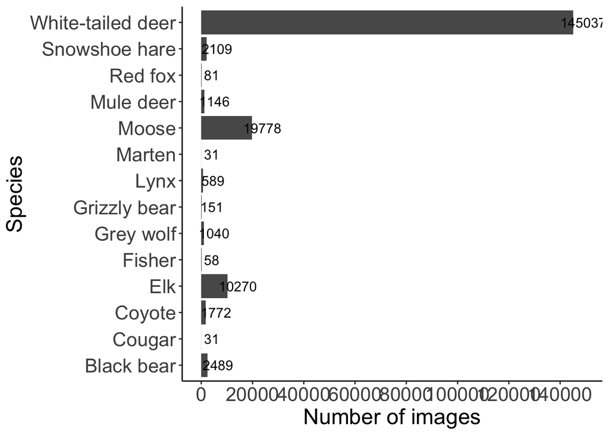

```r
image_plot <-

  srfn_data_fixed %>%

  filter(species %in% c(# focal species
    "Black bear",
    "Coyote",
    "Grey wolf",
    "Moose",
    "Lynx",
    "Snowshoe hare",
    "White-tailed deer",

    # additional species
    'Elk',
    'Mule deer',
    #'Red squirrel',
    'Grizzly bear',
    'Red fox',
    #'Human',
    'Fisher',
    #'Spruce grouse',
    'Cougar',
    'Marten'
   # 'Domestic dog',
    # 'Ruffed grouse',
    # 'Raven',
    # 'Owl'
  )) %>%

  # Convert species to a factor with alphabetical levels
  mutate(species = factor(as.character(species),
                          levels = sort(unique(as.character(species))))) %>%

  group_by(species) %>%



  summarise(count = n()) %>%

  ggplot(., aes(x = species,
                y = count)) +

  # add bars for each species
  geom_col() +

  # add the count printed above each column as text
  geom_text(aes(label = count,
                y = count + 4000),
            size = 4) +

  # specify smaller breaks for y-axis
  scale_y_continuous(breaks = seq(0, 150000, by = 20000)) +

  # generate custom labels for axis
  labs(x = 'Species',
       y = 'Number of images') +

  coord_flip() +

  theme_classic() +

  theme(axis.text = element_text(size = 16),
        axis.title = element_text(size = 18))
        #axis.text.x = element_text(angle = 90))

image_plot
```

### Save graph

```r
ggsave('srfn_all_images.jpg',
       image_plot,
       path = 'figures',
       width = 12,
       height = 10,
       units = 'in',
       dpi = 600
       )
```

## Independent detections

For the models we want to run we need data for the independent detections of each species at each site. We’ve defined independent detections as those at least 30 minutes apart.

The data manipulation and loop below will do this for us.

```r
# prep the data for calculating independent detections
srfn_det <- srfn_data_fixed %>%

  # select only variables of interest
  select(array,
         site_number,
         site,
         species,
         datetime,
         month,
         year) %>%

  # remove rows with no species info
  drop_na(species) %>%

  # now we need to create a new variable called timediff
  # first make sure data are arrange in proper order
  arrange(site_number, site, species, datetime) %>% # this will NOT work if not in correct order (early-late date)

  # create groups for each species at each site
  group_by(species, site) %>%

  # create new variable timediff that will calculate the difference
  mutate(timediff = as.numeric(difftime(datetime,lag(datetime),
                                        units = "mins")))


# set the independent detection threshold to 30 minutes
mins <- 30

# loop that assigns group ID
# identifies when there are photos/rows that are more than 30 mins apart
# Attributes an event ID
srfn_det$event_id <- 9999
seq <- as.numeric(paste0(nrow(srfn_det),0))
seq <- round(seq,-(nchar(seq)))

for (i in 2:nrow(srfn_det)) {
  srfn_det$event_id[i-1]  <- paste0("E",format(seq, scientific = F))
  if(is.na(srfn_det$timediff[i]) | abs(srfn_det$timediff[i]) > (mins)){
    seq <- seq + 1
  }
}

if(srfn_det$timediff[nrow(srfn_det)] < (mins)|
   is.na(srfn_det$timediff[nrow(srfn_det)])){
  srfn_det$event_id[nrow(srfn_det)] <- srfn_det$event_id[nrow(srfn_det)-1]
} else{srfn_det$event_id[nrow(srfn_det)] <- paste0("E",format(seq+1, scientific = F))
}

# now create a new data frame with a single row for each event
srfn_ind_det <- srfn_det %>%
  group_by(event_id) %>%
  filter(row_number()==1)

srfn_ind_det
```

```
## # A tibble: 8,428 × 9
## # Groups:   event_id [8,428]
##    array site_number site     species   datetime            month  year timediff
##    <chr> <fct>       <fct>    <fct>     <dttm>              <dbl> <dbl>    <dbl>
##  1 LUUK  100         LUUK_100 White-ta… 2022-05-23 03:06:03     5  2022      NA
##  2 LUUK  100         LUUK_100 White-ta… 2022-11-20 12:28:11    11  2022  261202.
##  3 LUUK  100         LUUK_100 White-ta… 2022-12-09 12:14:00    12  2022   27346.
##  4 LUUK  100         LUUK_100 White-ta… 2022-12-12 10:05:37    12  2022    4188.
##  5 LUUK  100         LUUK_100 Moose     2022-05-30 11:49:21     5  2022      NA
##  6 LUUK  100         LUUK_100 Moose     2022-05-31 15:30:36     5  2022    1661.
##  7 LUUK  100         LUUK_100 Moose     2022-09-02 16:18:21     9  2022  135400.
##  8 LUUK  100         LUUK_100 Moose     2022-09-18 08:26:00     9  2022   22544.
##  9 LUUK  100         LUUK_100 Moose     2022-10-03 13:48:35    10  2022   21922.
## 10 LUUK  100         LUUK_100 Moose     2022-11-10 10:34:25    11  2022   54526.
## # ℹ 8,418 more rows
## # ℹ 1 more variable: event_id <chr>
```

> I hate this loop/all the many steps to do this, remind me to try to find a more elegant/understandable way to do this step at a later date

### Save independent detections

Let’s also save this data file for later

```r
write_csv(srfn_ind_det,
          'data/processed/srfn_ind_det.csv')
```

## Graphs

### Indpendent detections for mammals

Now lets create a few quick figures to look at the detection data

```r
# Data visualization independent detections---------------------------------------------

# read in saved detection data if starting here
#detections <- read_csv('figures/srfn_ind_det.csv') %>%

detections <- srfn_ind_det %>%
  # change site, species and event_id to factor
  mutate_if(is.character,
            as.factor)
```

```
## `mutate_if()` ignored the following grouping variables:
## • Column `event_id`
```

```r
# check number of different species
sort(levels(srfn_ind_det$species))
```

```
##  [1] "ATVer"             "Black bear"        "Cougar"
##  [4] "Coyote"            "Domestic dog"      "Elk"
##  [7] "Fisher"            "Grey wolf"         "Grizzly bear"
## [10] "Human"             "Hunter"            "Lynx"
## [13] "Marten"            "Moose"             "Mule deer"
## [16] "Other"             "Other birds"       "Owl"
## [19] "Raven"             "Red fox"           "Red squirrel"
## [22] "Ruffed grouse"     "Snowshoe hare"     "Spruce grouse"
## [25] "Staff"             "Unknown"           "Unknown bear"
## [28] "Unknown deer"      "Unknown ungulate"  "White-tailed deer"
```

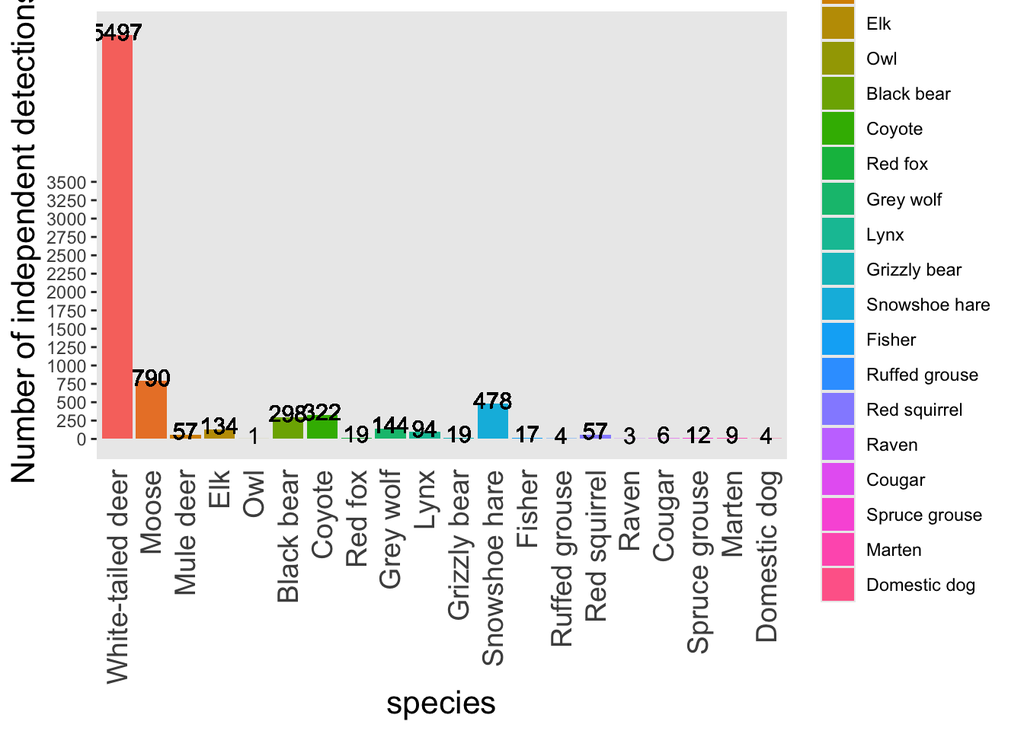

```r
# create a vector of the list of mammals to use for quick data visualization/exploration. Could also create a list of species that aren't useful if that is shorter and use filter(!species %in% OBJECTNAME) but for this example the vectors were about the same length
animals <- c('Black bear',
             'Cougar',
             'Coyote',
             'Domestic dog',
             'Elk',
             'Fisher',
             'Grey wolf',
             'Grizzly bear',
             'Lynx',
             'Marten',
             'Moose',
             'Mule deer',
             'Owl',
             'Raven',
             'Red fox',
             'Red squirrel',
             'Ruffed grouse',
             'Snowshoe hare',
             'Spruce grouse',
             'White-tailed deer'
            )

# remove NAs and select just images with mammals first then pipe new data into ggplot
det_graph <- detections %>%

  # remove less useful species
  filter(species %in% animals) %>%

  # get the number of individual detections per species to add to graph
  group_by(species) %>%

  mutate(n = n()) %>%

  ungroup() %>%

  ggplot(.,
         aes(x = species)) +

  # create bar graph of the counts of each spp in the data
  geom_bar(aes(fill = species)) +

  # add the number of detections above each bar using the variable n we calculated earlier
  geom_text(aes(label = n,
                y = n + 50),
            size = 4) +

  # change y axis label
  labs(y = 'Number of independent detections') +

  # change breaks for y axis
  scale_y_continuous(breaks = seq(0,3500, by = 250)) +

  # change theme elements
  theme(axis.text.x = element_text(angle = 90,
                                   vjust = 0.5,
                                   hjust = 1,
                                   size = 14),
        axis.title = element_text(size = 16),
        axis.ticks.x = element_blank(),
        panel.grid = element_blank())

# print graph
det_graph
```

If we want to save the plot for easier viewing later we can use the code below

```r
# save graph as jpeg (can also save as tiff, png, pdf by changing the file extension) but don't use .tiff in the github repo it takes up too much space and causes issues
ggsave("srfn_indv_det_graph.jpeg",
       det_graph,
       path = 'figures',
       width = 12,
       height = 10,
       units = 'in',
       dpi = 600)
```

### Independent detections per LU

let’s also create one that graphs each LU in it’s own panel using facet_wrap

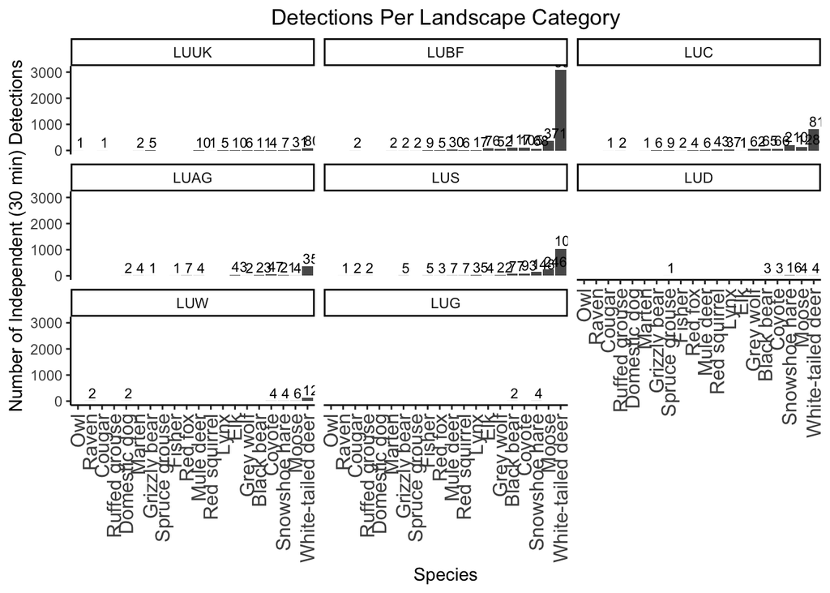

```r
# let's also create one that graphs each LU in it's own panel using facet_wrap
det_plot_LUs <- detections %>%

  # remove less useful species
  filter(species %in% animals) %>%

 # group by array and species to calculate dets per spp per LU
 group_by(array, species) %>%

  # calculate a column with unique accounts of each species
  reframe(count = n_distinct(event_id)) %>%

  # pipe to ggplot and set aesthetics mapping
  ggplot(aes(x = reorder(species, count), y = count)) +

  # plot as bar graph
  geom_col() +

  # plot each LU in own panel
  facet_wrap(vars(array)) +

  # add the number of detections at the end of each bar
  geom_text(aes(label = count),
            color = "black",
            size = 3,
            hjust = 0.2,
            vjust = -0.3) +

  # label x and y axis with informative titles
  labs(x = 'Species',
       y = 'Number of Independent (30 min) Detections') +

  # add title to plot with LU name

  ggtitle("Detections Per Landscape Category")+

  # set the theme
  theme_classic() +
  theme(plot.title = element_text(hjust = 0.5),
        axis.text.x = element_text(angle = 90,
                                   vjust = 0.5,
                                   hjust = 1,
                                   size = 12))

# view plot
det_plot_LUs
```

We can also save this plot if we want it for reports etc.

```r
# save this plot

ggsave('srfn_ind_det_per_LU.jpg',
       det_plot_LUs,
       dpi = 600,
       path = 'figures',
       width = 10,
       height = 12,
       units = 'in')
```

# Response metrics

there are several response metrics we can calculate, the ones we will cover here are.

1. Total independent detections per species/site
2. Presence/absence per species/site
3. Proportion of monthly detections

> Generally we only need #3 (proportional monthly detections) but we will also do #2 for some of the scarcer species of interst (grizzly bear and mule deer)

## Data

For this we need the deployment and independent detection data we created earlier, if you are still working through this script its the ‘deploy_fixed’ & ‘detections’ objects

```r
# deploy
deploy_fixed <- read_csv('data/processed/srfn_deploy_fixed.csv') %>%

  # instead of specifying how each column reads in because this was giving me issues with the date column for some reason we can adjust a couple columns that read in improperly here
  mutate(across(c(project_id:array), as.factor))
# detections
detections <- read_csv('data/processed/srfn_ind_det.csv') %>%

   # change site, species and event_id to factor
  mutate_if(is.character,
            as.factor) %>%

  # change species names to lowercase and replace spaces with'_'
  mutate(species = species %>%
           str_to_lower() %>%
           str_replace_all(' ', '_'))
```

Let’s look over both data sets again before we proceed

```r
str(deploy_fixed)
```

```
## tibble [64 × 6] (S3: tbl_df/tbl/data.frame)
##  $ project_id : Factor w/ 1 level "SRFN": 1 1 1 1 1 1 1 1 1 1 ...
##  $ site_number: Factor w/ 64 levels "1","2","4","6",..: 1 2 3 4 5 6 7 8 9 10 ...
##  $ site       : Factor w/ 64 levels "LUAG_119","LUAG_124",..: 46 32 40 56 48 6 28 30 31 33 ...
##  $ array      : Factor w/ 8 levels "LUAG","LUBF",..: 4 3 3 6 6 2 3 3 3 3 ...
##  $ start_date : Date[1:64], format: "2022-04-06" "2022-04-07" ...
##  $ end_date   : Date[1:64], format: "2023-10-03" "2023-10-04" ...
```

```r
str(detections)
```

```
## tibble [8,428 × 9] (S3: tbl_df/tbl/data.frame)
##  $ array      : Factor w/ 8 levels "LUAG","LUBF",..: 7 7 7 7 7 7 7 7 7 7 ...
##  $ site_number: num [1:8428] 100 100 100 100 100 100 100 100 100 100 ...
##  $ site       : Factor w/ 63 levels "LUAG_119","LUAG_124",..: 59 59 59 59 59 59 59 59 59 59 ...
##  $ species    : chr [1:8428] "white-tailed_deer" "white-tailed_deer" "white-tailed_deer" "white-tailed_deer" ...
##  $ datetime   : POSIXct[1:8428], format: "2022-05-23 03:06:03" "2022-11-20 12:28:11" ...
##  $ month      : num [1:8428] 5 11 12 12 5 5 9 9 10 11 ...
##  $ year       : num [1:8428] 2022 2022 2022 2022 2022 ...
##  $ timediff   : num [1:8428] NA 261202 27346 4188 NA ...
##  $ event_id   : Factor w/ 8428 levels "E0","E1","E10",..: 1 2 1113 2224 3335 4446 5557 6668 7779 8318 ...
```

For plotting and formatting proportional monthly detections we need to create a subset of the species in the detections data to just include several focal species we are interested in

```r
# create a list of focal species for filtering the data/plots
srfn_focal_species <- c('white-tailed_deer',
             'black_bear',
             'cougar',
             'coyote',
             'elk',
             'fisher',
             'grey_wolf',
             'grizzly_bear',
             'lynx',
             'marten',
             'moose',
             'mule_deer',
             'red_fox',
             'snowshoe_hare')
```

## 1. Total independent detections

The first response metric we will calculate is the total number of independent detections per species per site.

To do this we use the detections data we created earlier from the raw timelapse data. We need to group by site and species and then we can use the `summarise()` function with the `n()` function to count the total detections After that we ungroup the data so if we run an analysis or make a plot it doesn’t stay grouped and then we use the `pivot_wider()` function to make a column for each species and a row for each site.

Finally we need to replace any NAs with zeros (the `n()` function function won’t insert a zero if there aren’t any observations to count so these NAs are indeed zeros)

```r
total_detections <- detections %>%

  # group by site and species to count detections
  group_by(site, species) %>%

  # use summarise to count detections per species per site
  summarise(detections = n(),
            .groups = 'drop') %>%

  pivot_wider(names_from = species,
              values_from = detections) %>%

  # replace NAs with 0 in all species columns
  mutate(across(
    where(is.numeric),
    ~ replace_na(., 0))) %>%

  # join the original 'array' and 'site_number' columns back
  left_join(detections %>% select(site,
                                  array,
                                  site_number) %>%
              distinct(), by = "site") %>%

  # rearrange columns to move 'array' and 'site_number' to the front
  relocate(array, site_number,
           .before = site) %>%

  # ensure site_number is still a factor
  mutate(site_number = as.factor(site_number)) %>%

   # set the column names to lower case and replace the spaces with '_' (these are both personal preferences of mine)
  set_names(
    names(.) %>%
      tolower()%>%
      str_replace_all(pattern = ' ',
                      replacement = '_'))


head(total_detections)
```

```
## # A tibble: 6 × 33
##   array site_number site     black_bear coyote red_fox `white-tailed_deer`
##   <fct> <fct>       <fct>         <int>  <int>   <int>               <int>
## 1 LUAG  119         LUAG_119          4     21       4                  62
## 2 LUAG  124         LUAG_124          2      3       1                 141
## 3 LUAG  137         LUAG_137         17     23       2                 153
## 4 LUBF  104         LUBF_104          1      2       1                  48
## 5 LUBF  105         LUBF_105          0      0       0                  22
## 6 LUBF  12          LUBF_12           0      1       0                  32
## # ℹ 26 more variables: domestic_dog <int>, fisher <int>, grey_wolf <int>,
## #   grizzly_bear <int>, marten <int>, snowshoe_hare <int>, elk <int>,
## #   moose <int>, mule_deer <int>, unknown <int>, unknown_ungulate <int>,
## #   lynx <int>, cougar <int>, red_squirrel <int>, other <int>, atver <int>,
## #   unknown_deer <int>, unknown_bear <int>, other_birds <int>, human <int>,
## #   staff <int>, spruce_grouse <int>, hunter <int>, ruffed_grouse <int>,
## #   raven <int>, owl <int>
```

Now that this data is formatted we should save it to the data/processed folder for use later

```r
# save csv file to processed data folder
write_csv(total_detections,
          'data/processed/srfn_total_detections.csv')
```

We can also plot this data to see what it looks like

In the code below we create an object called site_detections_plot where we pipe the total detection data into the `ggplot()` function after doing some formatting to make it plot

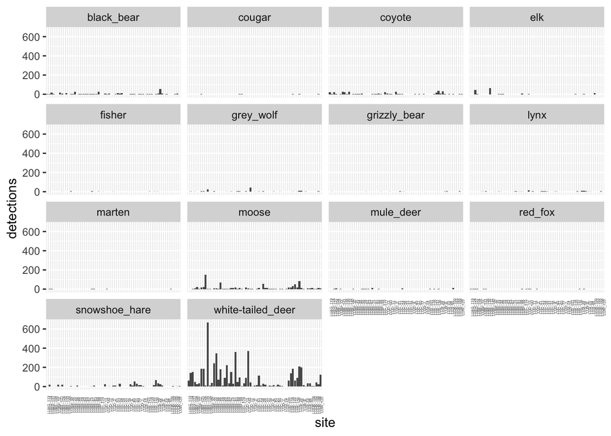

```r
site_detections_plot <-  total_detections %>%

  # we need to pivot longer to create species column again for plotting

  pivot_longer(cols = 4:33, # will need to adjust these numbers depending on the columns you have in your data each year
               names_to = 'species',
               values_to = 'detections') %>%

  # remove less useful species using a list created in the 'Graph independent detections' section: #KATE note: the original code was 'mammals' but remember we called it 'animals'
  #or we can try with only focal species - un-hash whichever line of code you want to use:
  #filter(species %in% animals) %>%
  filter(species %in% srfn_focal_species) %>%

  # pipe into ggplot function
ggplot(.,
       aes(x = site,
           y = detections)) +

  geom_col() +

  # use facet wrap to make separate plots for each species
  facet_wrap(vars(species)) +

  # shift axis text to 90 degrees so site name are readable
  theme(axis.text.x = element_text(angle = 90,
                                   size = 3),
        axis.ticks.x = element_blank())


# view plot
site_detections_plot
```

If we want to save the plot for easier viewing later we can use the code below

```r
# save graph as jpeg (can also save as tiff, png, pdf by changing the file extension)
ggsave('srfn_total_detections_site_focalspp.jpeg',
       site_detections_plot,
       path = 'figures',
       width = 12,
       height = 10,
       units = 'in',
       dpi = 600)
```

## 2. Presence/absences

One response metric we may want to use for those rarer species is simply presence/absence data. Here we can use the total_detections data and replace any values greater than 0 with 1s to create a binary variable.

```r
# we can use the data from above to create a similar response metric of simply presences and absences per species per site

species_presence <- total_detections %>%

  # replace all values above 0 with 1s
  mutate_if(is.numeric,
            ~1 * (. > 0))



# now we have presence absence data for all species
head(species_presence)
```

```
## # A tibble: 6 × 33
##   array site_number site     black_bear coyote red_fox `white-tailed_deer`
##   <fct> <fct>       <fct>         <dbl>  <dbl>   <dbl>               <dbl>
## 1 LUAG  119         LUAG_119          1      1       1                   1
## 2 LUAG  124         LUAG_124          1      1       1                   1
## 3 LUAG  137         LUAG_137          1      1       1                   1
## 4 LUBF  104         LUBF_104          1      1       1                   1
## 5 LUBF  105         LUBF_105          0      0       0                   1
## 6 LUBF  12          LUBF_12           0      1       0                   1
## # ℹ 26 more variables: domestic_dog <dbl>, fisher <dbl>, grey_wolf <dbl>,
## #   grizzly_bear <dbl>, marten <dbl>, snowshoe_hare <dbl>, elk <dbl>,
## #   moose <dbl>, mule_deer <dbl>, unknown <dbl>, unknown_ungulate <dbl>,
## #   lynx <dbl>, cougar <dbl>, red_squirrel <dbl>, other <dbl>, atver <dbl>,
## #   unknown_deer <dbl>, unknown_bear <dbl>, other_birds <dbl>, human <dbl>,
## #   staff <dbl>, spruce_grouse <dbl>, hunter <dbl>, ruffed_grouse <dbl>,
## #   raven <dbl>, owl <dbl>
```

We can save this to data/processed

```r
# save csv file to processed data folder
write_csv(species_presence,
          'data/processed/srfn_presence_absence.csv')
```

We may also want to plot this similarly to the total detections per site to look at the data easier

As before we create a new object with our plot title name and then pipe the data after some formatting into the `ggplot()` function.

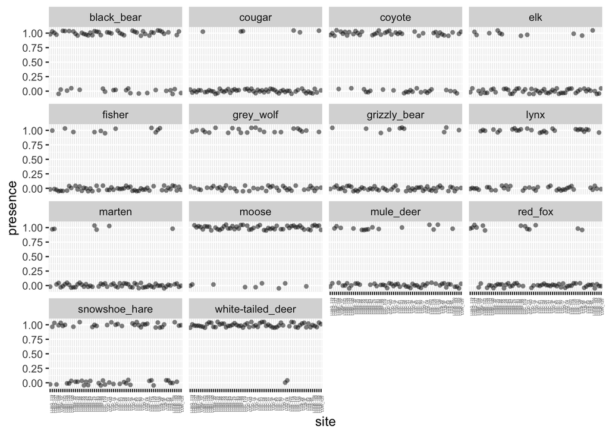

```r
# plot this data in ggplot
species_presence_plot <- species_presence %>%

  # first we need to pivot the data longer again so we have a species column for plotting
  pivot_longer(cols = 4:33,
               names_to = 'species',
               values_to = 'presence') %>%

  # remove less useful species using a list created in the 'Graph independent detections' section #KAte: going forward using srfn_focal_species refined list
  filter(species %in% srfn_focal_species) %>%

  # pipe into ggplot function
ggplot(.,
       aes(x = site, y = presence)) +

  # use geom_jitter instead of geom_point so we can shift points on y-axis to make them easier to view
  geom_jitter(shape = 16,
              size = 1.5,
              width = 0,
              height = 0.05,
              alpha = 0.5) +

  # use facet_wrap to make separate plots for each species so data is easier to look at
  facet_wrap(vars(species)) +

  # shift axis text to 90 degrees so site name are readable
  theme(axis.text.x = element_text(angle = 90,
                                   size = 3))



# view plot
species_presence_plot
```

If we want to save the plot for easier viewing later we can use the code below

```r
# save graph as jpeg (can also save as tiff, png, pdf by changing the file extension)
ggsave('srfn_presence_absence_site.jpeg',
       species_presence_plot,
       path = 'figures',
       width = 12,
       height = 10,
       units = 'in',
       dpi = 600)
```

## 3. Proportion monthly detections

The main response metric we want is generated here.

We need to use the deployment data to determine how many days each camera was active for

The script below, modified from Becca Smith’s MSc should do just that!

First we create a new data frame from the deploy_fixed (deployment data frame that’s been cleaned) with some of the same columns and a new column ‘day’ that goes from the start date to the end date of each camera deployment and increases by intervals of 1 (for each day the camera was active). We use this to calculate the number of days/month each camera was active for and create a new variable for this called days_month. and then we create another column based on the days/month the camera was active that classifies each month of data for a camera as keep or remove based on whether there were at least 15 active camera days in that month. This is because we don’t want to estimate monthly data for a camera that was working less than half the time.

```r
deploy_active <- deploy_fixed %>%

  # for each row, create a sequence between the start and end dates, and make a new row for that for each date
  rowwise() %>%
  do(data.frame(array = .$array,
                site_number = .$site_number,
                site = .$site,
                start = .$start_date,
                end = .$end_date,
                day = seq(.$start_date, .$end_date, by = "1 day"))) %>%
  # Create a new column that determines which month each of your dates is in
  mutate(month = month(day),
         year = year(day)) %>%

  # group by site, month and year
  group_by(site, month, year) %>%

  # Determine number of days per month camera is active
  mutate(days_month = length(unique(day))) %>%

  # get distinct rows for each
  distinct(site, month, year,
           .keep_all = TRUE) %>%

  # mark which months have < 15 days active to be removed later
  mutate(remove = case_when(days_month <15 ~ 'remove',
                            days_month >=15 ~ 'keep'))
```

Now we calculate the total number of months each camera was active for based on the new column we created (remove) for those active at least 15 days/month.

We will use this data again later

```r
# calculate the total number of months each camera was active for including only those active for >15 days/month or the 'keep' values

deploy_months_active <- deploy_active %>%

  # keep only months camera active >15 days
  filter(remove == 'keep') %>%

  # group by site and month
  group_by(site) %>%

  # count total number of months active
  summarise(months_active = n())

# we will use this data later
```

Now that we have identified cameras that were not active long enough each month to reliably extract data from we can use that column to remove this data from the detections data frame.

Then from the data we keep we can create a new data frame that has 1 row per camera and a column for each species indicating how many of the active months each species was detected at that camera.

```r
# now that we have  identified cameras that were not active long enough each month to reliably extract data from we can use that column to remove this data from the detections data frame

proportional_detections <- detections %>%

  # join data to the deploy_active data frame
  left_join(deploy_active,
            by = c('site',
                   'month',
                   'year')) %>%

  # filter by only those we identified as 'keep' (i.e. camera working >=15 days/month)
  filter(remove == 'keep') %>%

  # get a distinct row for each species at each site for each month and year
  distinct(site,
           species,
           month,
           year) %>%

  # group by site and species to create data frame with one row per site x species combo
  group_by(site,
           species) %>%

  summarise(months_present = n()) %>%

  # ungroup data
  ungroup() %>%

  # filter to only species in the list of focal species we created earlier
  # NOTE when we do this we lose 3 sites because there weren't any of these species detected at those sites during months where the camera was active >= 15 days/month
  filter(species %in% srfn_focal_species) %>%

  # pivot the data wider so there is a column for each species and 1 row per site
  pivot_wider(names_from = species,
              values_from = months_present) %>%

  # replace NAs with zeros in all species columns
  mutate(across(
    where(is.numeric),
    ~ replace_na(., 0))) %>%

  # add column for total months each camera was active from the deploy_months_active object we created earlier

  left_join(deploy_months_active,
            by = 'site') %>%

  # ensure all species columns are numeric not integer
  mutate_if(is.integer,
            as.numeric)
```

Now we can run the function below to create a second column for each species that will represent the number of absences (months the species was not detected) at each camera from the active months.

> Important note, you will need to change the column numbers in the function below if your data frame is a different lenght

```r
# run a function to create columns for absences based on presence data and how many months the camera was functioning

# first convert data to data frame not a tibble for function to work
proportional_detections <- as.data.frame(proportional_detections)

# create a vector of the species columns for the loop
# use all species columns (this value may change year to year)
cols <- 2:15

for (col in cols) {
  if (is.numeric(proportional_detections[,col]) & is.numeric(proportional_detections[,16]))
    {new_col_name <- paste0("absent_", colnames(proportional_detections)[col])
    proportional_detections[new_col_name] <- proportional_detections[,16] - proportional_detections[,col]
  }
}
```

Now we have to do a bit of final wrangling of the data to fix the bear columns because we don’t want to consider the months that bears are not active in the months active columns.

```r
# fix bear data

# before we can use this data we need to adjust the columns for bears since they are hibernating we don't want to calculate their presence/absence for those inactive months

# now let's recalculate the number of active months
months_active_bears <- deploy_active %>%

  # filter to months bears are active (April - November)
  dplyr::filter(month %in% c("4", "5", "6", "7", "8", "9", "10", "11")) %>%

  # get distinct rows for each
  distinct(site, month, year,
           .keep_all = TRUE) %>%

  # group by site
  group_by(site) %>%

  # count the number of months active during bear active season and save as new column
  summarise(months_active_bears = n())




# now we overwrite the absent column for black bears using new info

proportional_detections_bears <- proportional_detections %>%

  # join the bear active data
  left_join(months_active_bears,
            by = 'site') %>%

  # overwrite absent black bear column
  mutate(absent_black_bear = months_active_bears - black_bear,
         absent_grizzly_bear = months_active_bears - grizzly_bear) %>%

  # get rid of unnecessary columns for active months
  select(-c(months_active,
            months_active_bears))
```

Finally we can save this data

```r
# save data
write_csv(proportional_detections_bears,
          'data/processed/srfn_proportional_detections.csv')
```

Let’s also try to plot the presence data at least for each species so we can see which species we likely have enough data for to model

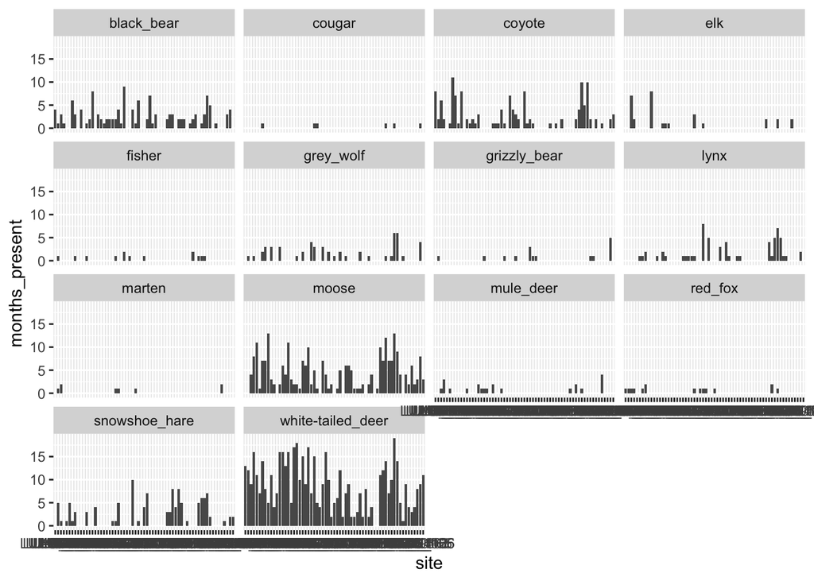

```r
# first reformat the data so species presence is a column
proportional_detection_plot <- proportional_detections_bears %>%

  pivot_longer(cols = c('black_bear':'cougar'),
               names_to = 'species_presence',
               values_to = 'months_present') %>%

  select(site, species_presence, months_present) %>%

  ggplot(aes(x = site, y = months_present)) +

  # plot as bars
  geom_col() +

  # use facet wrap to generate separate plots for each species
  facet_wrap(vars(species_presence))

# view plot
proportional_detection_plot
```

If we want to save the plot for easier viewing later we can use the code below

```r
# save graph as jpeg (can also save as tiff, png, pdf by changing the file extension)
ggsave('srfn_proportional_detections.jpeg',
       proportional_detection_plot,
       path = 'figures',
       width = 12,
       height = 10,
       units = 'in',
       dpi = 600)
```

Ready to work with the covariates now!!! Proceed to script #2